# Brazil: Univariate animal model tutorial

Alastair Wilson

9/6/2016

# Genetic and environmental effects on vole size

Imagine a study of voles showed bigger animals have higher fitness – they are more likely on average to survive and or reproduce. So vole size is under positive selection, but will it evolve and if so how fast? The answer depends on the extent to which size variation comes from genetic effects versus environmental effects (e.g., variation in forage quality).

Lets imagine we have a sample of 500 voles caught in the field, measured and sampled for DNA. Although not from a breeding design by genotyping at a suite of molecular markers the family structures (i.e. pedigree) was determined. The pedigree spans two generation (100 parents, 400 offspring). Data on forage quality at the site of each individual’s capture were also collected.

# set working directory

You will need to set your working directory, and make sure it contains the two data files voles2.txt and volesPED. Then we can read the data into R.

```r
#1. read in the main data file
voles<-read.table("voles2.txt", header=T)
voles$ID<-as.factor(voles$ID)
voles$sex<-as.factor(voles$sex)
voles$SIRE<-as.factor(voles$SIRE)
voles$DAM<-as.factor(voles$DAM)

#read in the pedigree file
volesPED<-read.table("volesPED.txt",header=T)
```

Before we do anything else, let’s load up some packages we are going to use

```r
#2. Automatically installs packages in this list that user does not already have

list_pkgs <- c("lme4","lmerTest","MCMCglmm","pedantics","pedigreemm")
new_pkgs <- list_pkgs[!(list_pkgs %in% installed.packages()[,"Package"])]
if(length(new_pkgs) > 0){ install.packages(new_pkgs) }

library(pedantics)
library(MCMCglmm)
library(lme4)
library(lmerTest)
library(pedigreemm)
```

## Data structure

Let’s look at the file structures just so we know what our data look like

```r
#3. Data structure
head(voles)
```

```
##      ID aggression     size sex SIRE  DAM      forage
## 401 401   3.675307 23.25477   1 <NA> <NA> -0.14936773
## 402 402   9.898771 17.23754   1 <NA> <NA> -1.14433949
## 403 403   9.549621 20.03212   1 <NA> <NA>  0.45325762
## 404 404   5.139761 24.35055   1 <NA> <NA>  0.12827954
## 405 405   3.819785 21.54173   1 <NA> <NA>  0.03174167
## 406 406   3.368013 18.36796   1 <NA> <NA>  0.54561204
```

```r
head(volesPED)
```

```
##    ID DAM SIRE
## 1 401  NA   NA
## 2 402  NA   NA
## 3 403  NA   NA
## 4 404  NA   NA
## 5 405  NA   NA
## 6 406  NA   NA
```

Hopefully this is self explanatory! You can include information on father (SIRE) and mother (DAM) in the main data file (as has been done here) although for various reasons it is often more convenient to have a separate pedigree data file as well when running animal models. Note that the separate pedigree file is arranged so that every vole must appear in the “individual” column before it can appear as a parent. In practice this means the oldest generation will be at the top of the file and parents for these individuals will be unknown so NA.

We can also represent the pedigree graphically, for instance using the R package **Pedantics**.

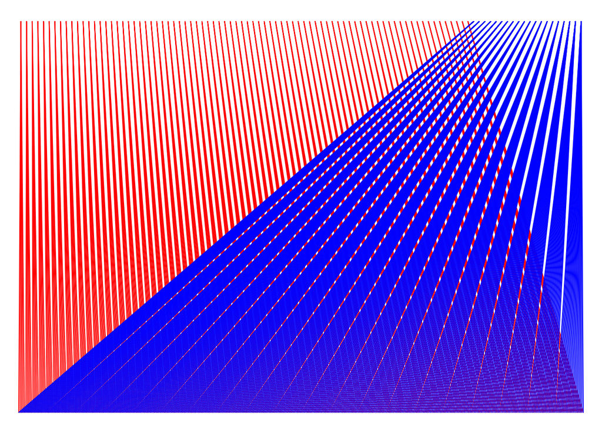

```r
#4. Draw a pedigree!
drawPedigree(volesPED)
```

Here red lines represent maternal links and blue represent paternal. This structure is actually a half-sib full-sib design that I used to simulate data over (so not really what you’d get from a study of wild voles at all, but could be obtained in a lab experiment). Just for comparison have a look at this real pedigree structure from a wild population of red deer that live on the Scottish island of Rum.

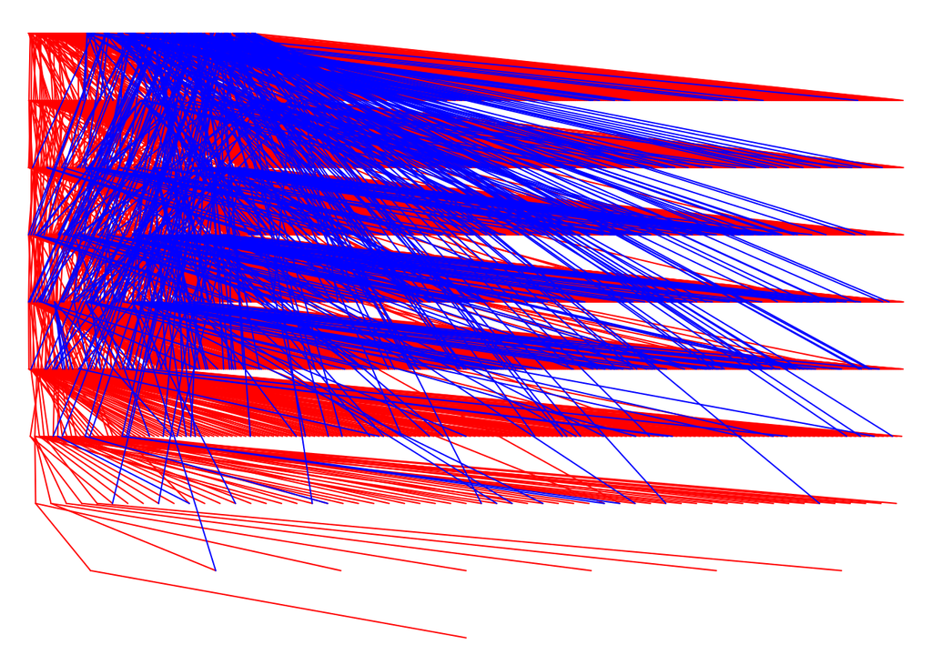

```r
#5. Read in the Run red deer (Cervus elaphus) pedigree file (old version!)
deerPED<-read.table("deer.ped",header=T)

#and draw it using default settings in Pedantics
drawPedigree(deerPED)
```

## Estimating VA for body size in voles

Given that the data we are going to use is actually simulated over a simple full-sib half-sib design for the second generation (as opposed to a complex multigenerational pedigree structure), and we also have phenotypes for the parens we have options of how to analyse the data, so we’ll try a few different approaches.

## 1. Simple ANOVA of sibship data

Parent-offspring regression could be done here, but we’ll pass over that and try ANOVA as a simple starting point. This is appropriate here if we only use phenotypic data from the offspring generation. For this generation the date are balanced (equal numbers of offspring per dam and dams per sire) with no missing phenotypes.

Note that confusingly the anova command in R is used generically to compare models/test model terms for significance, while R uses aov to call an ordinary least squares ANOVA.

```r
#6. Run an ANOVA
mod_aov<-aov(size~SIRE, data=voles, na.action=na.omit)
                      # this will drop parental generation for us since they have missing SIRE
summary(mod_aov)
```

The output should be like this:

```
##              Df Sum Sq Mean Sq F value   Pr(>F)
## SIRE         19  546.5  28.761   6.686 3.43e-15 ***
## Residuals   380 1634.5   4.301
## ---
## Signif. codes:  0 '***' 0.001 '**' 0.01 '*' 0.05 '.' 0.1 ' ' 1
## 100 observations deleted due to missingness
```

The sire effect is statistically significant, meaning there is genetic variance. We could run a two factor ANOVA by making the model formula size~SIRE+DAM if we wanted (try it!). We could also use this statistical model to calculate heritability. However, the output is provided in terms of Sum Sq not variance on the actual data scale so in order to avoid a lot of looking up formulae and doing arithmetic let’s switch to a simpler to interpret mixed model framework.

## 2. Sire-dam model fitted by REML

First we’ll use **LME4** as a generic package for fitting simple mixed models (i.e. where random factors have repeated observations) by REML. So we can fit sire as a random effect on size, summarise the model to see the estimate of Vsire, and test its significance using a likelihood ratio test.

```r
#8. Mixed model with SIRE as random
mod_sire<-lmer(size~(1|SIRE), data=voles, na.action=na.omit)
                         #note parents will be kicked out still due to unknown SIRES

summary(mod_sire)
rand(mod_sire)            #this will test significance of random effects using LRT
```

### Expanding the model

However, full-sibs also share a mother so it’s probably better to model that non-indpendence too. Ignoring it could potentially lead to an inflated estimate of SIRE variance. Remembering this is a field study in which environmental factors could not be experimentally controlled, we might want to **control statistically** for any effects of variable forage quality on body size too. Finally, we may also want to control for any sexual dimorphism in body size.

It’s always worth looking at the data of course to see if effects of forage or sex are readily apparent!

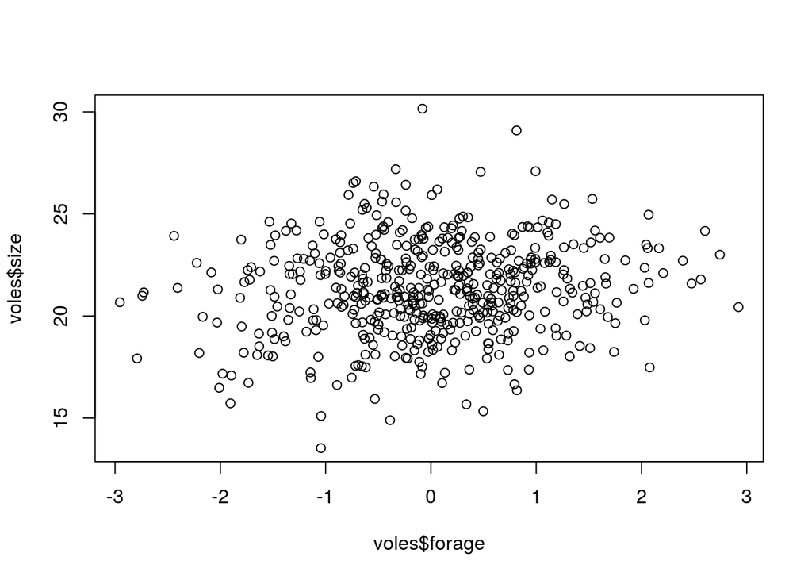

```r
#9. Look at the data
plot(voles$forage, voles$size)
```

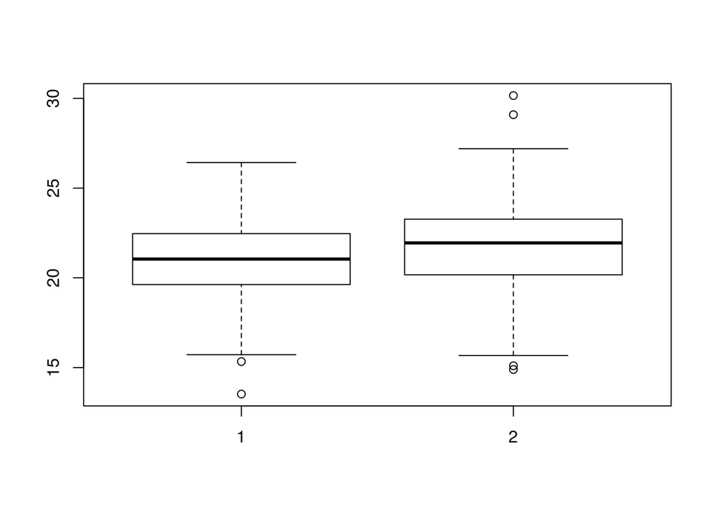

```r
plot(voles$sex, voles$size)  #sex 1 is female, 2 is male
```

Nothing jumps out here, but let’s include them as a fixed covariates and test them formally, along with an extra random effect. We can always simplify fixed effects later, for example if we want to retain only significant terms in a final model.

```r
#10. A SIRE-DAM MODEL
mod_sire_dam<-lmer(size~sex+forage+ (1|SIRE)+(1|DAM), data=voles, na.action=na.omit)
        #note parents will be kicked out still due to unknown SIRES and DAMS
```

Using **rand** as above we should find that DAM and SIRE variances are both are significant.

```
## Analysis of Random effects Table:
##      Chi.sq Chi.DF p.value
## SIRE   14.5      1   1e-04 ***
## DAM    18.2      1   2e-05 ***
## ---
## Signif. codes:  0 '***' 0.001 '**' 0.01 '*' 0.05 '.' 0.1 ' ' 1
```

The model **summary** reveals that the two variances are of similar size, and that there are actually significant (albeit quite small) effects of sex and forage on vole size.

[output not shown]

Sometimes using a sire-dam model you find that **Vdam** is much bigger than **Vsire**. This can indicate important dominance or maternal effect contributions. In this case the simulatiion parameters included additive effects only, so I was expecting the two variances to be similar.

### Calculate an estimate of h<sup>2</sup>

Remembering that for this breeding design **Vsire=0.25VA** and that total phenotypic variance **VP** can be defined (conditional on fixed effects) as the sum of all variance components, we can calculate an estimate of heritability:

```r
#11. Calculate h2
h2_sire_dam=(4*1.0155)/(0.8224+1.0155+3.4693)
h2_sire_dam
```

```
## [1] 0.7653753
```

Before leaving this model we should really look at some residual plots to check we are happy that the standard assumptions of homogeneous variance and Gaussian errors are reasonable….

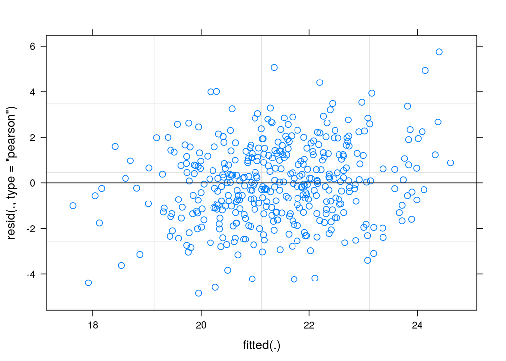

```r
#12. Check model residuals
plot(mod_sire_dam)             #plots fitted against residual
```

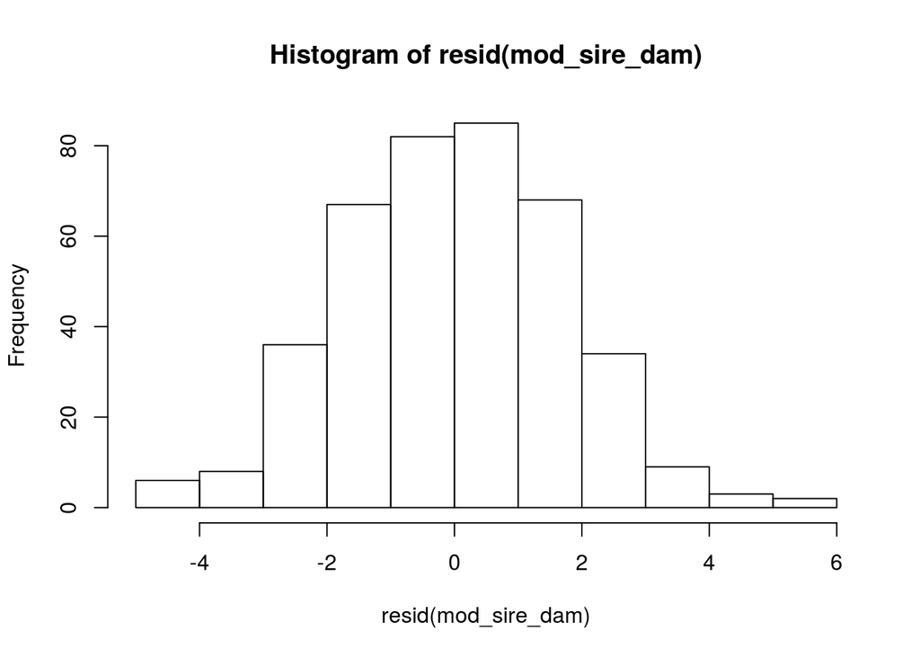

```r
hist(resid(mod_sire_dam))      #check distribution of residuals
```

which they are!

## 3. Animal model fitted by REML

### Software options

Unfortunately not many generic REML mixed model packages can fit animal models. I use **ASReml-R** which is very powerful and flexible mixed model package that allows you fit basic animal models and extend them in all sorts of interesting ways for quantitative genetic application. However it is not free and we don’t have access to it today. **WOMBAT** is good free REML program but has to be run outside of R.

So for now we will use a package called **pedigreemm** which interfaces with **LME4**. These packages are really a bit useless not ideal for fitting animal models, but for illustrative purposes we can use them to estimate h<sup>2</sup> in a simple scenario. Later we will fit the same animal model using **MCMCglmm**. This is powerful and free mixed model package for R that can fit animal models. However **MCMCglmm** requires us to adopt some Bayesian thinking (which has both advantages and disadvantages) and more extensive post-fitting model checks to make sure we “believe” the results.

### Fitting the model

**pedigreemm** needs a pedigree file separate from the main data file, but in a slightly different format to the one we have. So we’ll restructure the file a little. Then we fit the animal model, keeping fixed effects as above, but replacing the random effects **SIRE** and **DAM** with an effect of the focal individual’s own genes (i.e. its breeding value). This is done by fitting **ID** in the model, but linking it to the pedigree structure.

```r
#13.Animal model in pedigreemm
volesPED2<-pedigree(volesPED$SIRE,volesPED$DAM,volesPED$ID)  #restructure ped file

mod_animalREML<-pedigreemm(size~sex+forage+(1|ID),pedigree=list(ID=volesPED2),
                   data=voles, REML=TRUE,
                   control=lmerControl(check.nobs.vs.nlev="ignore",
                                       check.nobs.vs.nRE="ignore"))
```

*Note the control arguments above are to overide standard LME4 checks for for repeated observations within each level of random effect. Such repeats are normally needed in simple mixed models, but not in an animal model.*

Now check the residual plots using **plot(mod_animalREML)** and **hist(resid(mod_animalREML))** before calling the model summary:

```r
#14. Summarise the model
summary(mod_animalREML)
```

```
## Linear mixed model fit by REML ['lmerpedigreemm']
## Formula: size ~ sex + forage + (1 | ID)
##    Data: voles
## Control:
## lmerControl(check.nobs.vs.nlev = "ignore", check.nobs.vs.nRE = "ignore")
##
## REML criterion at convergence: 2150.5
##
## Scaled residuals:
##      Min       1Q   Median       3Q      Max
## -2.29066 -0.54643 -0.01826  0.56947  2.75949
##
## Random effects:
##  Groups   Name        Variance Std.Dev.
##  ID       (Intercept) 2.252    1.501
##  Residual             2.615    1.617
## Number of obs: 500, groups:  ID, 500
##
## Fixed effects:
##             Estimate Std. Error t value
## (Intercept) 20.93889    0.18834  111.17
## sex2         0.80969    0.18230    4.44
## forage       0.28035    0.09156    3.06
##
## Correlation of Fixed Effects:
##        (Intr) sex2
## sex2   -0.289
## forage -0.014  0.088
```

The ID variance is now a direct estimate of the variance in breeding values, that is the additive genetic variance **VA**. We can calculate the heritability estimate (conditional on fixed effects) as:

```r
#15. And calculate h2
h2_animalREML=2.252/(2.252+2.615)
h2_animalREML
```

```
## [1] 0.462708
```

### Why are the two estimates of heritability so different?

The sire-dam model yields an estimate of h<sup>2</sup>=0.765 which is notably higher that the animal model estimate of h<sup>2</sup>=0.463. Why is this? In fact both are valid estimates and neither approach is inherently **biased** in this case. Since the data were simulated I actually know in this case that the lower estimate is much closer to the “truth” (i.e. the h<sup>2</sup> that was set for the hypothetical population from which parents were randomly drawn). Of course in real situations the truth is unknown - but the animal model estimate is expected to better in the sense of being more precise because:

1. While sample size is quite low for a quantitative genetic study anyway, the **sire-dam model is unable to utilise all phenotypic data available here**. It cannot use the parental phenotype data.
2. **The sire-dam model does not utilise the data efficiently**. The estimate of VA is really driven by a comparison of within-paternal half sibship mean phenotypes of which there are just 20. Using a sire-dam model (and assuming additive inheritance only) it is the number of sires, rather than dams per sire or offspring per dam that is the key limitation on precision.
3. **The animal model uses all the data with maximal efficiency**. The estimate of VA is being informed by all possible pairwise comparisons among individuals. This includes parent-offspring, full-sib, half-sib and unrelated individuals.

### Characterising uncertainty

The pedigreemm/LME4 combination here doesn’t readily generate measures of uncertainty (e.g., SE or CI) on VA or h<sup>2</sup> under either model. We could probably come up with a method (e.g. bootstrapping) but the coding is non-trivial. Quantifying uncertainty on quantitative genetic parameters is important and this limitation is a good reason to work with more specialist packages. For instance using **ASReml-R** (code not shown) estimates of VA and h<sup>2</sup> are (reassuringly!) the same to those to those obtained above. However this program also estimates SE which, though approximate for technical reasons, give a clear picture of the relative precision of the two modelling strategies. It’s also easy to test VA (and any other variance components) using likelihood ratio tests in ASReml.

**ASReml sire_dam model** Vsire = 1.02 (0.457), VA = 4.06 (1.83), h<sup>2</sup> = 0.765 (0.290)

**ASReml animal model** VA = 2.25 (0.480), h<sup>2</sup> = 0.463 (0.078)